# Final Tutorial: Economic Freedom of the World

# Name: Danni Feng

[figure not shown]

## Introduction

This tutorial will introduce the ways of data collection & data processing, exploratory analysis & visualization, analysis, hypothesis testing & ML, and coressponding insights.

I'm using a dataset containing the economic freedom and related variables from 5 areas (size of government, legal structure and security of property rights, access to sound money, freedom to trade internationally, and regulation of credit, labour and business) to investigate the relationship amomg the economic freedom and other variables so that we can improve the economic freedom.

My goals of studying economic freedom of the world are as follows:

- data tyding and get rid of missing data
- feature selection: select the areas that are strongly related to economic freedom based on the data visualization of distribution, trend , scatter plot, heatmap and hypothesis testing of the coefficent.
- build models for predicting economic freedom, and evaluate model using r^2, p-value, f-test, prediced value v.s actual value plot
- get insights on the performance of 5 countries, after adopting the optimal models for predicting economic freedom
- investigate a new variable 'more_freedom' which is a catigorical variable indicating if the country has relative more freedom or not, and use Logistic regression and K-nearest Neighbors (KNN) Classification Model to predict the 'more_freedom' variable.
- evalutate Logistic regression and KNN model using Test/Training Split method
- give some suggestions on improving economic freedom according to the previous analysis

## 1. Data Collection and Data Processing

### retrieving data

First, I read data from a csv file, and store the data in a pandas dafarame

```python
import pandas as pd
import numpy as np
import matplotlib.pyplot as plt
from pandas.plotting import scatter_matrix
import statsmodels.formula.api as sm
import sklearn
from sklearn import feature_selection
import statsmodels.api as sma
from sklearn.linear_model import LogisticRegression
from sklearn import metrics
from sklearn import preprocessing
from sklearn.cross_validation import train_test_split
from sklearn.neighbors import KNeighborsClassifier
import seaborn as sns
```

```python
#raw data
raw_df=pd.read_csv('efw_cc.csv')
raw_df.head()
```

|  | year | ISO_code | countries | ECONOMIC FREEDOM | rank | quartile | 1a_government_consumption | 1b_transfers | 1c_gov_enterprises | 1d_top_marg_tax_rate | ... | 3_sound_money | 4a_tariffs | 4b_regulatory_trade_barriers | 4c_black_market | 4d_control_movement_capital_ppl | 4_trade | 5a_credit_market_reg | 5b_labor_market_reg | 5c_business_reg | 5_regulation |
| --- | --- | --- | --- | --- | --- | --- | --- | --- | --- | --- | --- | --- | --- | --- | --- | --- | --- | --- | --- | --- | --- |
| 0 | 2016 | ALB | Albania | 7.54 | 34.0 | 1.0 | 8.232353 | 7.509902 | 8.0 | 8.0 | ... | 9.553657 | 8.963556 | 7.489905 | 10.00000 | 6.406138 | 8.214900 | 7.098562 | 6.916278 | 6.705863 | 6.906901 |
| 1 | 2016 | DZA | Algeria | 4.99 | 159.0 | 4.0 | 2.150000 | 7.817129 | 0.0 | 4.5 | ... | 7.253894 | 6.872533 | 2.481294 | 5.56391 | 1.590362 | 4.127025 | 5.100509 | 5.029513 | 5.676956 | 5.268992 |
| 2 | 2016 | AGO | Angola | 5.17 | 155.0 | 4.0 | 7.600000 | 8.886739 | 0.0 | 9.5 | ... | 5.606605 | 6.989244 | 2.024949 | 10.00000 | 2.044823 | 5.264754 | 7.064905 | 4.560325 | 4.930271 | 5.518500 |
| 3 | 2016 | ARG | Argentina | 4.84 | 160.0 | 4.0 | 5.335294 | 6.048930 | 6.0 | 4.0 | ... | 5.614336 | 6.421600 | 4.811105 | 0.00000 | 4.697482 | 3.982547 | 5.419820 | 5.151405 | 5.535831 | 5.369019 |
| 4 | 2016 | ARM | Armenia | 7.57 | 29.0 | 1.0 | 7.264706 | 7.748532 | 8.0 | 5.0 | ... | 9.521940 | 8.547556 | 7.194410 | 10.00000 | 6.830998 | 8.143241 | 9.102046 | 6.234630 | 6.797530 | 7.378069 |

5 rows × 36 columns

### Tyding data

First, I replace all the empty entires with NaN, and then I drop the rows with NaN value to get rid of the missing data.

Second, I rename the econmic freedom column as EF, making it easier to refer variables

```python
#dealing with missing data: replace empty cells with NaN
raw_df.replace('',np.nan,inplace=True)
raw_df.head(25)
```

|  | year | ISO_code | countries | ECONOMIC FREEDOM | rank | quartile | 1a_government_consumption | 1b_transfers | 1c_gov_enterprises | 1d_top_marg_tax_rate | ... | 3_sound_money | 4a_tariffs | 4b_regulatory_trade_barriers | 4c_black_market | 4d_control_movement_capital_ppl | 4_trade | 5a_credit_market_reg | 5b_labor_market_reg | 5c_business_reg | 5_regulation |
| --- | --- | --- | --- | --- | --- | --- | --- | --- | --- | --- | --- | --- | --- | --- | --- | --- | --- | --- | --- | --- | --- |
| 0 | 2016 | ALB | Albania | 7.54 | 34.0 | 1.0 | 8.232353 | 7.509902 | 8.0 | 8.0 | ... | 9.553657 | 8.963556 | 7.489905 | 10.00000 | 6.406138 | 8.214900 | 7.098562 | 6.916278 | 6.705863 | 6.906901 |
| 1 | 2016 | DZA | Algeria | 4.99 | 159.0 | 4.0 | 2.150000 | 7.817129 | 0.0 | 4.5 | ... | 7.253894 | 6.872533 | 2.481294 | 5.56391 | 1.590362 | 4.127025 | 5.100509 | 5.029513 | 5.676956 | 5.268992 |
| 2 | 2016 | AGO | Angola | 5.17 | 155.0 | 4.0 | 7.600000 | 8.886739 | 0.0 | 9.5 | ... | 5.606605 | 6.989244 | 2.024949 | 10.00000 | 2.044823 | 5.264754 | 7.064905 | 4.560325 | 4.930271 | 5.518500 |
| 3 | 2016 | ARG | Argentina | 4.84 | 160.0 | 4.0 | 5.335294 | 6.048930 | 6.0 | 4.0 | ... | 5.614336 | 6.421600 | 4.811105 | 0.00000 | 4.697482 | 3.982547 | 5.419820 | 5.151405 | 5.535831 | 5.369019 |
| 4 | 2016 | ARM | Armenia | 7.57 | 29.0 | 1.0 | 7.264706 | 7.748532 | 8.0 | 5.0 | ... | 9.521940 | 8.547556 | 7.194410 | 10.00000 | 6.830998 | 8.143241 | 9.102046 | 6.234630 | 6.797530 | 7.378069 |
| 5 | 2016 | AUS | Australia | 7.98 | 10.0 | 1.0 | 4.511765 | 6.664948 | 10.0 | 5.0 | ... | 9.452540 | 8.820000 | 7.427103 | 10.00000 | 3.859781 | 7.526721 | 9.576358 | 7.698589 | 8.121631 | 8.465526 |
| 6 | 2016 | AUT | Austria | 7.58 | 27.0 | 1.0 | 3.744118 | 3.101062 | 10.0 | 3.5 | ... | 9.432830 | 8.266133 | 8.254011 | 10.00000 | 5.906786 | 8.106733 | 9.129015 | 5.565118 | 7.419870 | 7.371334 |
| 7 | 2016 | AZE | Azerbaijan | 6.49 | 106.0 | 3.0 | 6.320588 | 7.881208 | 0.0 | 6.5 | ... | 7.513487 | 7.973778 | 6.799052 | 10.00000 | 4.093268 | 7.216525 | 7.467778 | 6.076782 | 7.080078 | 6.874880 |
| 8 | 2016 | BHS | Bahamas | 7.34 | 49.0 | 2.0 | 7.085294 | 9.040503 | 7.0 | 10.0 | ... | 6.890104 | 3.253067 | 8.105925 | 10.00000 | 5.384615 | 6.685902 | 8.622733 | 8.361606 | 7.523034 | 8.169125 |
| 9 | 2016 | BHR | Bahrain | 7.56 | 30.0 | 1.0 | 3.688235 | 9.581704 | 10.0 | 10.0 | ... | 9.404353 | 8.523200 | 6.295595 | 10.00000 | 4.794819 | 7.403403 | 7.609167 | 6.619418 | 8.018774 | 7.415786 |
| 10 | 2016 | BGD | Bangladesh | 6.30 | 120.0 | 3.0 | 9.455882 | 9.724590 | 7.0 | 8.0 | ... | 6.983617 | 6.541200 | 3.238636 | 10.00000 | 4.377655 | 6.039373 | 7.884084 | 7.223647 | 4.962580 | 6.690103 |
| 11 | 2016 | BRD | Barbados | 6.43 | 111.0 | 3.0 | 7.564495 | 5.968942 | 6.0 | 6.0 | ... | 6.404613 | 7.282578 | 5.661880 | 10.00000 | 5.415145 | 7.089901 | 6.286333 | 7.139467 | 6.148503 | 6.524768 |
| 12 | 2016 | BLR | Belarus | 6.23 | 123.0 | 4.0 | 5.085294 | 4.460490 | 10.0 | 7.5 | ... | 5.332777 | 7.704356 | 9.728995 | 10.00000 | 1.269605 | 7.175739 | 3.850618 | 7.188794 | 8.092322 | 6.377245 |
| 13 | 2016 | BEL | Belgium | 7.32 | 52.0 | 2.0 | 2.491176 | 2.010416 | 10.0 | 1.0 | ... | 9.377366 | 8.266133 | 8.057299 | 10.00000 | 6.481454 | 8.201222 | 9.606066 | 7.327516 | 7.374380 | 8.102654 |
| 14 | 2016 | BLZ | Belize | 6.86 | 83.0 | 3.0 | 6.632643 | 8.431260 | 4.0 | 9.0 | ... | 7.204524 | 6.619111 | 6.873193 | 10.00000 | 4.709434 | 7.050435 | 9.947942 | 7.018917 | 6.684745 | 7.883868 |
| 15 | 2016 | BEN | Benin | 5.98 | 134.0 | 4.0 | 7.458824 | 9.771475 | 4.0 | 3.5 | ... | 7.013885 | 6.807733 | 4.712944 | 10.00000 | 2.585506 | 6.026546 | 8.487923 | 5.937581 | 6.142281 | 6.855929 |
| 16 | 2016 | BTN | Bhutan | 7.02 | 73.0 | 2.0 | 4.447059 | 9.899420 | 7.0 | 8.5 | ... | 6.720911 | 6.471778 | 7.433688 | 10.00000 | 1.424686 | 6.332538 | 7.765472 | 8.664285 | 6.674658 | 7.701472 |
| 17 | 2016 | BOL | Bolivia | 6.23 | 123.0 | 4.0 | 5.814706 | 8.836512 | 0.0 | 10.0 | ... | 9.386300 | 7.749178 | 3.981030 | 10.00000 | 6.217961 | 6.987042 | 7.630667 | 3.948479 | 3.346666 | 4.975271 |
| 18 | 2016 | BIH | Bosnia and Herzegovina | 6.60 | 98.0 | 3.0 | 5.582353 | 5.352167 | 4.0 | 6.5 | ... | 8.315906 | 8.551867 | 7.169369 | 10.00000 | 5.417871 | 7.784777 | 9.561234 | 7.399741 | 5.279863 | 7.413612 |
| 19 | 2016 | BWA | Botswana | 7.43 | 44.0 | 2.0 | 3.644118 | 7.164033 | 7.0 | 9.0 | ... | 9.056783 | 5.944000 | 7.514894 | 10.00000 | 7.259208 | 7.679525 | 8.856753 | 7.509680 | 6.942897 | 7.769777 |
| 20 | 2016 | BRA | Brazil | 5.75 | 144.0 | 4.0 | 4.714706 | 5.786374 | 4.0 | 6.0 | ... | 7.972060 | 7.261778 | 5.508447 | 10.00000 | 5.230938 | 7.000291 | 4.540031 | 4.149861 | 3.590036 | 4.093309 |
| 21 | 2016 | BRN | Brunei Darussalam | 6.93 | 77.0 | 2.0 | 0.000000 | NaN | NaN | 10.0 | ... | 8.797459 | 9.258400 | 3.761357 | 10.00000 | 5.199615 | 7.054843 | 9.128576 | 8.686708 | 7.513954 | 8.443079 |
| 22 | 2016 | BGR | Bulgaria | 7.41 | 46.0 | 2.0 | 5.747059 | 5.846512 | 8.0 | 8.5 | ... | 9.439349 | 8.266133 | 7.604036 | 10.00000 | 6.619250 | 8.122355 | 9.610572 | 7.035682 | 6.191990 | 7.612748 |
| 23 | 2016 | BFA | Burkina Faso | 6.05 | 129.0 | 4.0 | 3.121846 | 10.000000 | 2.0 | 6.5 | ... | 7.121434 | 7.367733 | 4.538209 | 10.00000 | 4.510639 | 6.604145 | 9.008980 | 7.158336 | 6.115344 | 7.427554 |
| 24 | 2016 | BDI | Burundi | 5.92 | 138.0 | 4.0 | 5.961765 | 10.000000 | 2.0 | 6.5 | ... | 7.585471 | 6.897956 | 2.403250 | 10.00000 | 5.141875 | 6.110770 | 5.000000 | 7.803310 | 6.012328 | 6.271879 |

25 rows × 36 columns

```python
# drop the raws with missing data
new_df=raw_df.dropna()
# change columns' name
new_df=new_df.rename(columns={'ECONOMIC FREEDOM':'EF'})
new_df.head(25)
```

|  | year | ISO_code | countries | EF | rank | quartile | 1a_government_consumption | 1b_transfers | 1c_gov_enterprises | 1d_top_marg_tax_rate | ... | 3_sound_money | 4a_tariffs | 4b_regulatory_trade_barriers | 4c_black_market | 4d_control_movement_capital_ppl | 4_trade | 5a_credit_market_reg | 5b_labor_market_reg | 5c_business_reg | 5_regulation |
| --- | --- | --- | --- | --- | --- | --- | --- | --- | --- | --- | --- | --- | --- | --- | --- | --- | --- | --- | --- | --- | --- |
| 0 | 2016 | ALB | Albania | 7.54 | 34.0 | 1.0 | 8.232353 | 7.509902 | 8.0 | 8.0 | ... | 9.553657 | 8.963556 | 7.489905 | 10.000000 | 6.406138 | 8.214900 | 7.098562 | 6.916278 | 6.705863 | 6.906901 |
| 1 | 2016 | DZA | Algeria | 4.99 | 159.0 | 4.0 | 2.150000 | 7.817129 | 0.0 | 4.5 | ... | 7.253894 | 6.872533 | 2.481294 | 5.563910 | 1.590362 | 4.127025 | 5.100509 | 5.029513 | 5.676956 | 5.268992 |
| 2 | 2016 | AGO | Angola | 5.17 | 155.0 | 4.0 | 7.600000 | 8.886739 | 0.0 | 9.5 | ... | 5.606605 | 6.989244 | 2.024949 | 10.000000 | 2.044823 | 5.264754 | 7.064905 | 4.560325 | 4.930271 | 5.518500 |
| 3 | 2016 | ARG | Argentina | 4.84 | 160.0 | 4.0 | 5.335294 | 6.048930 | 6.0 | 4.0 | ... | 5.614336 | 6.421600 | 4.811105 | 0.000000 | 4.697482 | 3.982547 | 5.419820 | 5.151405 | 5.535831 | 5.369019 |
| 4 | 2016 | ARM | Armenia | 7.57 | 29.0 | 1.0 | 7.264706 | 7.748532 | 8.0 | 5.0 | ... | 9.521940 | 8.547556 | 7.194410 | 10.000000 | 6.830998 | 8.143241 | 9.102046 | 6.234630 | 6.797530 | 7.378069 |
| 5 | 2016 | AUS | Australia | 7.98 | 10.0 | 1.0 | 4.511765 | 6.664948 | 10.0 | 5.0 | ... | 9.452540 | 8.820000 | 7.427103 | 10.000000 | 3.859781 | 7.526721 | 9.576358 | 7.698589 | 8.121631 | 8.465526 |
| 6 | 2016 | AUT | Austria | 7.58 | 27.0 | 1.0 | 3.744118 | 3.101062 | 10.0 | 3.5 | ... | 9.432830 | 8.266133 | 8.254011 | 10.000000 | 5.906786 | 8.106733 | 9.129015 | 5.565118 | 7.419870 | 7.371334 |
| 7 | 2016 | AZE | Azerbaijan | 6.49 | 106.0 | 3.0 | 6.320588 | 7.881208 | 0.0 | 6.5 | ... | 7.513487 | 7.973778 | 6.799052 | 10.000000 | 4.093268 | 7.216525 | 7.467778 | 6.076782 | 7.080078 | 6.874880 |
| 9 | 2016 | BHR | Bahrain | 7.56 | 30.0 | 1.0 | 3.688235 | 9.581704 | 10.0 | 10.0 | ... | 9.404353 | 8.523200 | 6.295595 | 10.000000 | 4.794819 | 7.403403 | 7.609167 | 6.619418 | 8.018774 | 7.415786 |
| 10 | 2016 | BGD | Bangladesh | 6.30 | 120.0 | 3.0 | 9.455882 | 9.724590 | 7.0 | 8.0 | ... | 6.983617 | 6.541200 | 3.238636 | 10.000000 | 4.377655 | 6.039373 | 7.884084 | 7.223647 | 4.962580 | 6.690103 |
| 13 | 2016 | BEL | Belgium | 7.32 | 52.0 | 2.0 | 2.491176 | 2.010416 | 10.0 | 1.0 | ... | 9.377366 | 8.266133 | 8.057299 | 10.000000 | 6.481454 | 8.201222 | 9.606066 | 7.327516 | 7.374380 | 8.102654 |
| 17 | 2016 | BOL | Bolivia | 6.23 | 123.0 | 4.0 | 5.814706 | 8.836512 | 0.0 | 10.0 | ... | 9.386300 | 7.749178 | 3.981030 | 10.000000 | 6.217961 | 6.987042 | 7.630667 | 3.948479 | 3.346666 | 4.975271 |
| 19 | 2016 | BWA | Botswana | 7.43 | 44.0 | 2.0 | 3.644118 | 7.164033 | 7.0 | 9.0 | ... | 9.056783 | 5.944000 | 7.514894 | 10.000000 | 7.259208 | 7.679525 | 8.856753 | 7.509680 | 6.942897 | 7.769777 |
| 20 | 2016 | BRA | Brazil | 5.75 | 144.0 | 4.0 | 4.714706 | 5.786374 | 4.0 | 6.0 | ... | 7.972060 | 7.261778 | 5.508447 | 10.000000 | 5.230938 | 7.000291 | 4.540031 | 4.149861 | 3.590036 | 4.093309 |
| 22 | 2016 | BGR | Bulgaria | 7.41 | 46.0 | 2.0 | 5.747059 | 5.846512 | 8.0 | 8.5 | ... | 9.439349 | 8.266133 | 7.604036 | 10.000000 | 6.619250 | 8.122355 | 9.610572 | 7.035682 | 6.191990 | 7.612748 |
| 23 | 2016 | BFA | Burkina Faso | 6.05 | 129.0 | 4.0 | 3.121846 | 10.000000 | 2.0 | 6.5 | ... | 7.121434 | 7.367733 | 4.538209 | 10.000000 | 4.510639 | 6.604145 | 9.008980 | 7.158336 | 6.115344 | 7.427554 |
| 26 | 2016 | CMR | Cameroon | 5.82 | 141.0 | 4.0 | 7.379412 | 9.567100 | 7.0 | 4.5 | ... | 7.222024 | 5.495733 | 2.363001 | 10.000000 | 2.360348 | 5.054771 | 7.166555 | 7.334712 | 5.088875 | 6.530047 |
| 27 | 2016 | CAN | Canada | 7.98 | 10.0 | 1.0 | 3.923529 | 7.172716 | 8.0 | 5.0 | ... | 9.579712 | 7.047600 | 7.922217 | 10.000000 | 6.747176 | 7.929248 | 9.712141 | 8.179867 | 7.652364 | 8.514791 |
| 31 | 2016 | CHL | Chile | 7.80 | 15.0 | 1.0 | 6.629412 | 7.891642 | 10.0 | 7.0 | ... | 9.331413 | 9.470667 | 7.029769 | 10.000000 | 6.573816 | 8.268563 | 8.947500 | 5.170611 | 7.176759 | 7.098290 |
| 32 | 2016 | CHN | China | 6.46 | 108.0 | 3.0 | 3.861765 | 8.294278 | 2.0 | 6.0 | ... | 8.542427 | 8.211422 | 6.220092 | 10.000000 | 2.403916 | 6.708858 | 7.133781 | 5.539548 | 6.400861 | 6.358063 |
| 33 | 2016 | COL | Colombia | 6.50 | 105.0 | 3.0 | 5.097059 | 7.840214 | 10.0 | 4.5 | ... | 7.973965 | 7.820356 | 4.319063 | 9.534426 | 5.569296 | 6.810785 | 8.882960 | 5.837184 | 6.413232 | 7.044459 |
| 34 | 2016 | COD | Congo, Dem. R. | 5.67 | 148.0 | 4.0 | 7.676471 | 8.850409 | 8.0 | 4.0 | ... | 7.345706 | 7.750756 | 2.017237 | 10.000000 | 2.270817 | 5.509702 | 6.333333 | 5.805844 | 5.107181 | 5.748786 |
| 36 | 2016 | CRI | Costa Rica | 7.55 | 33.0 | 1.0 | 5.435294 | 8.501325 | 10.0 | 6.5 | ... | 9.779738 | 7.962311 | 6.090374 | 10.000000 | 7.961562 | 8.003562 | 6.798088 | 6.145051 | 6.404254 | 6.449131 |
| 37 | 2016 | CIV | Cote d'Ivoire | 6.00 | 132.0 | 4.0 | 7.335294 | 9.958249 | 4.0 | 2.0 | ... | 7.176292 | 5.774400 | 2.929834 | 10.000000 | 3.216521 | 5.480189 | 8.693333 | 5.930779 | 6.203657 | 6.942590 |
| 38 | 2016 | HRV | Croatia | 6.96 | 75.0 | 2.0 | 4.438235 | 4.297315 | 8.0 | 2.0 | ... | 9.136324 | 8.568356 | 8.306176 | 10.000000 | 5.878025 | 8.188139 | 9.409518 | 6.372156 | 6.081176 | 7.287616 |

25 rows × 36 columns

## 2. Exploratory Analysis and Visualization

I try to visualize data to explore some insights and potential repationships.

### a.Economic Freedom Distribution and trend

The code below produces the plots that illustrate the distribution of economic freedom across countries from 2005-2016 In order to plot the distribution. I create a crosstab, so we can plot all the countries' distributions on one plot

In addition, use the economic freedom mean to show the central tencency.

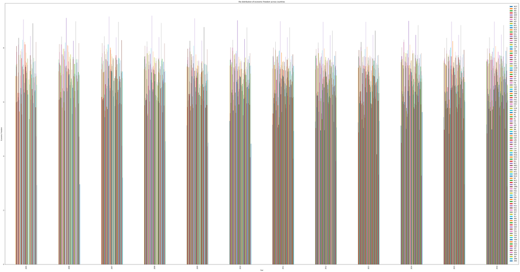

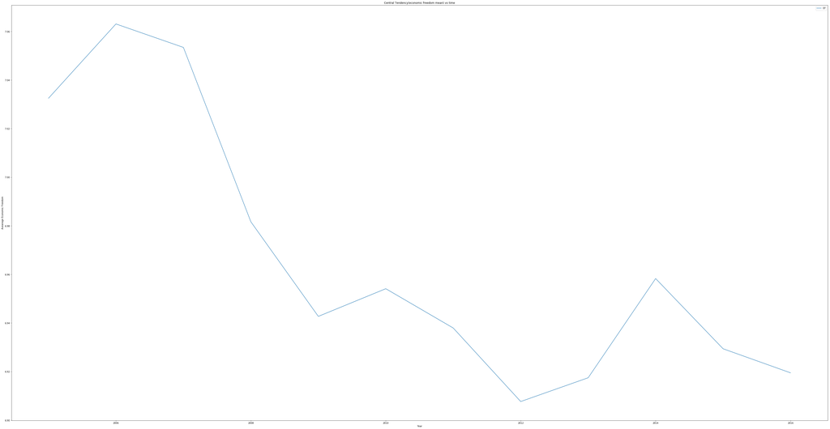

```python
#create a crosstab, so we can plot all the countries' distributions on one plot
cross_chart=pd.crosstab(new_df.year,new_df.ISO_code,new_df.EF,aggfunc='sum')

#set the plot size
plt.rcParams['figure.figsize'] = (65, 34)
#plot the bar chart
cross_chart.plot.bar()



#set the x,y label
plt.xlabel("Year")
plt.ylabel("Economic Freedom")
plt.title("the distribution of economic freedom across countries")
#relocate the lengend
plt.legend(loc='right')

#use the economic freedom mean to show the central tencency.
#First, calculate the average economic freedom of each year,
#and create a new table called mean_trend to show the relationship between year and mean
mean_trend=(new_df[['year','EF']].groupby('year')).mean()
mean_trend.plot.line()

#set the x,y label
plt.xlabel("Year")
plt.ylabel("Avearage Economic Freedom")
plt.title("Central Tendency(economic freedom mean) vs time")



plt.show()
```

### Conclusion 1:

According to the distribution and central tendency plot above, the economic freedom is generally decreasing over time

### b. correlation among each variable

- In this part, I'm roughly looking for the areas that strongly affect the economic freedom by comparing the correlation between the economic freedom and other variables.
- The areas that strongly affect the economic freedom should be the ones that are strongly correlated to economic freedom

#### Method1: Scatter matrix plot

- In order to determine the pairs of variables that are strongly related, I plot a scatter matrix composed of all the possible scatter plots. A linear scatter plot indicates that the corresponding two variables are strongly correlated.

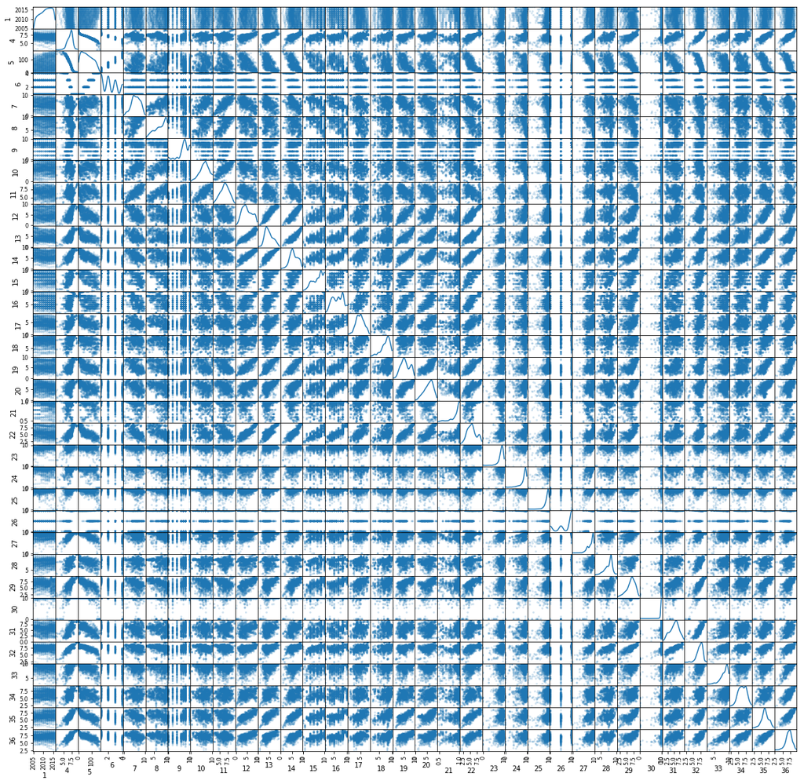

```python
clean_df=new_df.copy()
#label each variable with numbers to make plot clearer
clean_df.columns=['1','2','3','4','5','6','7','8','9','10','11','12','13','14','15','16','17','18','19','20','21','22','23','24','25','26','27','28','29','30','31','32','33','34','35','36']
scatter_matrix(clean_df,alpha=0.2,figsize=(20,20),diagonal='kde')
plt.show()
```

#### Method2: Heatmap

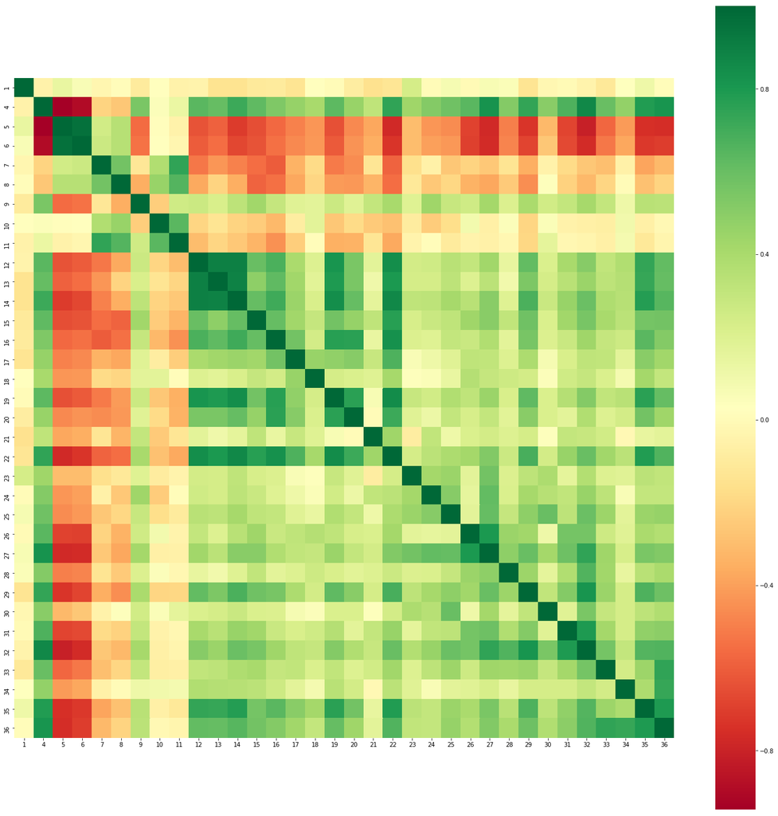

```python
sns.heatmap(clean_df.corr(),square=True,cmap='RdYlGn')
plt.show()
```

### Conclusion2:

According to the scatter matrix plot/heatmap, the Freedom to Trade Internationally area and the Regulation area affect the economic freedom most

## 3. Analysis, hypothesis testing & ML

In this step, my goal is to build and evaluate models that fits best using the variables I got in Step2 as well as year, and I will use that model to predict the econmic freedom.

In addition, I will also build and evaluate models for predicting a new catigrical variable 'more_freedom'

## Part 1: regression analysis

In part1, the goal is to figure out the better model for predicting the economic freedom.

1. model building: we will use univariate linear regression and multivariate linear regression to predict the economic freedom.
2. model evaluation: we will use 4 ways to evaluate the model:

   ```
    - a. r^2
    - b. p-value
    - c. F-test
    - d. prediced value v.s actual value plot
   ```

### MODEL1: univariate linear regression

```python
clean_df2=clean_df.copy()
clean_df2.columns=['year','ISO','3','EF','5','6','7','8','9','10','size_gov','12','13','14','15','16','17','18','19','20','21','property_rights','23','24','25','26','sound_money','28','29','30','31','trade','33','34','35','regulation']
regr_model1=sm.ols(formula='EF~year',data=clean_df2).fit()
predict1=regr_model1.predict(clean_df2[['year','trade','regulation']])
print(regr_model1.summary())
```

```
                            OLS Regression Results
==============================================================================
Dep. Variable:                     EF   R-squared:                       0.002
Model:                            OLS   Adj. R-squared:                  0.002
Method:                 Least Squares   F-statistic:                     3.111
Date:                Wed, 12 Dec 2018   Prob (F-statistic):             0.0780
Time:                        05:11:22   Log-Likelihood:                -1644.6
No. Observations:                1316   AIC:                             3293.
Df Residuals:                    1314   BIC:                             3304.
Df Model:                           1
Covariance Type:            nonrobust
==============================================================================
                 coef    std err          t      P>|t|      [0.025      0.975]
------------------------------------------------------------------------------
Intercept     31.2087     13.747      2.270      0.023       4.240      58.177
year          -0.0121      0.007     -1.764      0.078      -0.025       0.001
==============================================================================
Omnibus:                      202.817   Durbin-Watson:                   1.977
Prob(Omnibus):                  0.000   Jarque-Bera (JB):              464.850
Skew:                          -0.866   Prob(JB):                    1.15e-101
Kurtosis:                       5.341   Cond. No.                     1.19e+06
==============================================================================

Warnings:
[1] Standard Errors assume that the covariance matrix of the errors is correctly specified.
[2] The condition number is large, 1.19e+06. This might indicate that there are
strong multicollinearity or other numerical problems.
```

### MODEL2: multiple linear regression

```python
regr_model2=sm.ols(formula='EF~year+trade+regulation',data=clean_df2).fit()
predict2=regr_model2.predict(clean_df2[['year','trade','regulation']])
print(regr_model2.summary())
```

```
                            OLS Regression Results
==============================================================================
Dep. Variable:                     EF   R-squared:                       0.852
Model:                            OLS   Adj. R-squared:                  0.852
Method:                 Least Squares   F-statistic:                     2516.
Date:                Wed, 12 Dec 2018   Prob (F-statistic):               0.00
Time:                        05:10:48   Log-Likelihood:                -389.34
No. Observations:                1316   AIC:                             786.7
Df Residuals:                    1312   BIC:                             807.4
Df Model:                           3
Covariance Type:            nonrobust
==============================================================================
                 coef    std err          t      P>|t|      [0.025      0.975]
------------------------------------------------------------------------------
Intercept     14.4120      5.313      2.712      0.007       3.988      24.836
year          -0.0067      0.003     -2.541      0.011      -0.012      -0.002
trade          0.4784      0.012     41.102      0.000       0.456       0.501
regulation     0.3637      0.012     30.119      0.000       0.340       0.387
==============================================================================
Omnibus:                        3.824   Durbin-Watson:                   1.994
Prob(Omnibus):                  0.148   Jarque-Bera (JB):                3.797
Skew:                          -0.097   Prob(JB):                        0.150
Kurtosis:                       3.178   Cond. No.                     1.19e+06
==============================================================================

Warnings:
[1] Standard Errors assume that the covariance matrix of the errors is correctly specified.
[2] The condition number is large, 1.19e+06. This might indicate that there are
strong multicollinearity or other numerical problems.
```

```python
#Perform F test that compares how well two models fit my data
anova1=sma.stats.anova_lm(regr_model1,type=2)
anova2=sma.stats.anova_lm(regr_model2,type=2)

print('F-test on year-only: \n')
print(anova1)
print('\nF-test on 3 variables: \n')
print(anova2)
```

```
F-test on year-only:

              df      sum_sq   mean_sq         F    PR(>F)
year         1.0    2.220915  2.220915  3.110884  0.078003
Residual  1314.0  938.087740  0.713918       NaN       NaN

F-test on 3 variables:

                df      sum_sq     mean_sq            F         PR(>F)
year           1.0    2.220915    2.220915    20.927166   5.221914e-06
trade          1.0  702.581085  702.581085  6620.257675   0.000000e+00
regulation     1.0   96.269419   96.269419   907.124276  6.399136e-152
Residual    1312.0  139.237237    0.106126          NaN            NaN
```

```
Text(0.5,1,'prediced value v.s actual value plot for model 2')
```

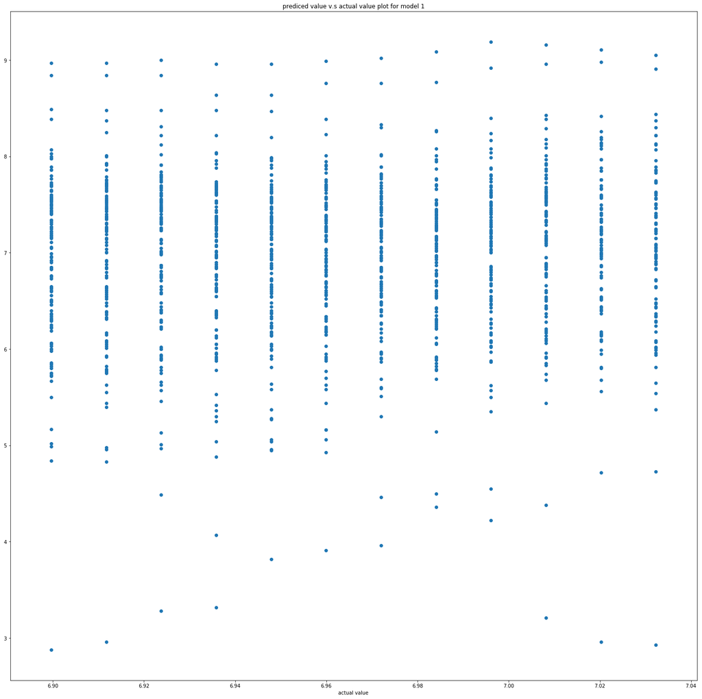

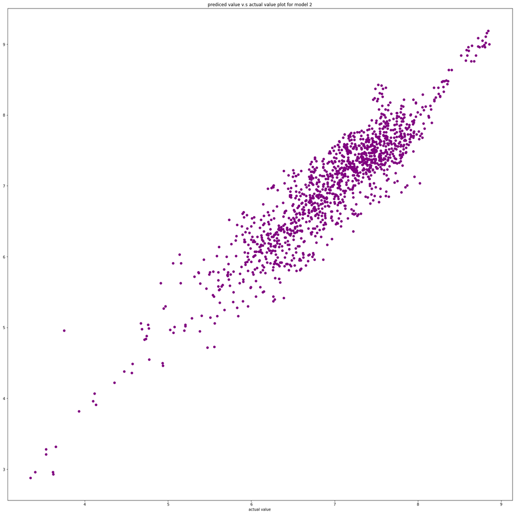

```python
#prediced value v.s actual value plot
plt.scatter(predict1,clean_df2['EF'])
plt.xlabel('predicted value')
plt.xlabel('actual value')
plt.title('prediced value v.s actual value plot for model 1')

plt.subplots()
plt.scatter(predict2,clean_df2['EF'],color='purple')
plt.xlabel('predicted value')
plt.xlabel('actual value')
plt.title('prediced value v.s actual value plot for model 2')
```

### Therefore, we should adopt MODEL2 to predict economic freedom, and the corresponding linear regression equation is y= -0.0067*year+0.4784*trade+0.3637*regulation+14.412

## Which countries have relative bad performance on econmic freedom?

After adoping MODEL2, I want to show:

- Among United States, United Kingdom, China, Germany, and Japan, which countries have relative bad performance on econmic freedom?
- Define performance as acutal economic freedom - expected economic freedom

```
Text(0.5,1,'Performance of USA,GBR,CHN,DEU,JPN')
```

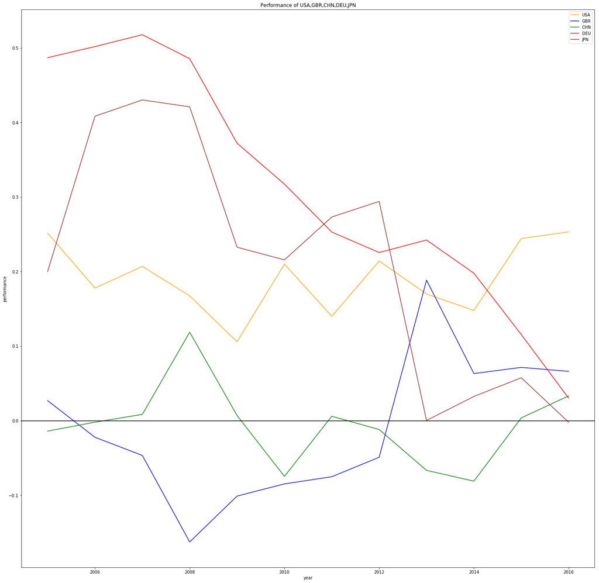

```python
perform=clean_df2.copy()

perform['expected']=0.0

for index,row in perform.iterrows():
    expected=-0.0067*row['year']+0.4784*row['trade']+0.3637*row['regulation']+14.412
    perform.at[index,'expected']=expected

#create a new column, storing the performance = acutal economic freedom - expected economic freedom
perform['performance']=0.0
for index,row in perform.iterrows():
    performance=row['EF']-row['expected']
    perform.at[index,'performance']=performance


usa=perform.groupby('ISO').get_group('USA')
gbr=perform.groupby('ISO').get_group('GBR')
chn=perform.groupby('ISO').get_group('CHN')
deu=perform.groupby('ISO').get_group('DEU')
jpn=perform.groupby('ISO').get_group('JPN')

fig,ax=plt.subplots()

usa.plot.line('year','performance',ax=ax,color='orange',label='USA')
gbr.plot.line('year','performance',ax=ax,color='blue',label='GBR')
chn.plot.line('year','performance',ax=ax,color='green',label='CHN')
deu.plot.line('year','performance',ax=ax,color='red',label='DEU')
jpn.plot.line('year','performance',ax=ax,color='brown',label='JPN')

plt.axhline(0,color='black')
plt.xlabel('year')
plt.ylabel('performance')
plt.title('Performance of USA,GBR,CHN,DEU,JPN')
```

## Part 2: Classification

In this part, I will investigate a new variable 'more_freedom' which is a catigorical variable indicating if the country has relative more freedom or not

1. model building: We will use Logistic regression and K-nearest Neighbors (KNN) Classification Model to predict the 'more_freedom' variable.
2. model evalution:

   a. use "training accuracy" as the evaluation metric by calculating the proportion of correct predictions

   b. procedure: We will use Train and test on the split dataset procedure instead of Train and test on the entire dataset procedure to evaluate the dataset because the latter procedure will produce unnecessarily complex models overfit the training data. The steps of first procedure are:

   ```
    -Split the dataset into two pieces: a training set and a testing set.
    -Train the model on the training set.
    -Test the model on the testing set, and evaluate how well we did.
   ```

```python
#add one more column 'more_freedom' indicating if it has more economic freedom, 1 means it does have more economic freedom
#otherwise, assign 0 to 'more_freedom'

clean_df2['more_freedom']=1
#mean of economic freedom
mean=(clean_df2['EF']).mean()

for index, row in clean_df2.iterrows():
    if(row['EF']<mean):
        clean_df2.at[index,'more_freedom']=0
```

### MODEL3: Logistic regression

```python
X=clean_df2[['size_gov','property_rights','sound_money','year','trade','regulation']]

#change the y variable into categorical values
y=clean_df2['more_freedom']

#split X and y into training and testing sets
X_train, X_test, y_train, y_test = train_test_split(X, y, test_size=0.4, random_state=4)

#instantiate the model
logreg = LogisticRegression()

#fit the model with data
logreg.fit(X_train, y_train)

#predict the response values for the observations in X
#and store the predicted response values
y_pred = logreg.predict(X_test)

# compute classification accuracy for the logistic regression model

print('Training accuracy: ',metrics.accuracy_score(y_test, y_pred))
```

```
Training accuracy:  0.990512333966
```

### the training accuracy of MODEL3 is 0.990512333966, which is pretty high

### MODEL4: K-nearest Neighbors (KNN) Classification Model

```python
#Locate a relative good value for K

# try K=1 through K=25 and record testing accuracy
k_range = range(1, 26)

# We can create Python dictionary using [] or dict()
scores = []

# We use a loop through the range 1 to 26
# We append the scores in the dictionary
for k in k_range:
    knn = KNeighborsClassifier(n_neighbors=k)
    knn.fit(X_train, y_train)
    y_pred = knn.predict(X_test)
    scores.append(metrics.accuracy_score(y_test, y_pred))

print('Training accuracy for all the possible k:\n',scores)
```

[output not shown]

```
Text(0,0.5,'Testing Accuracy')
```

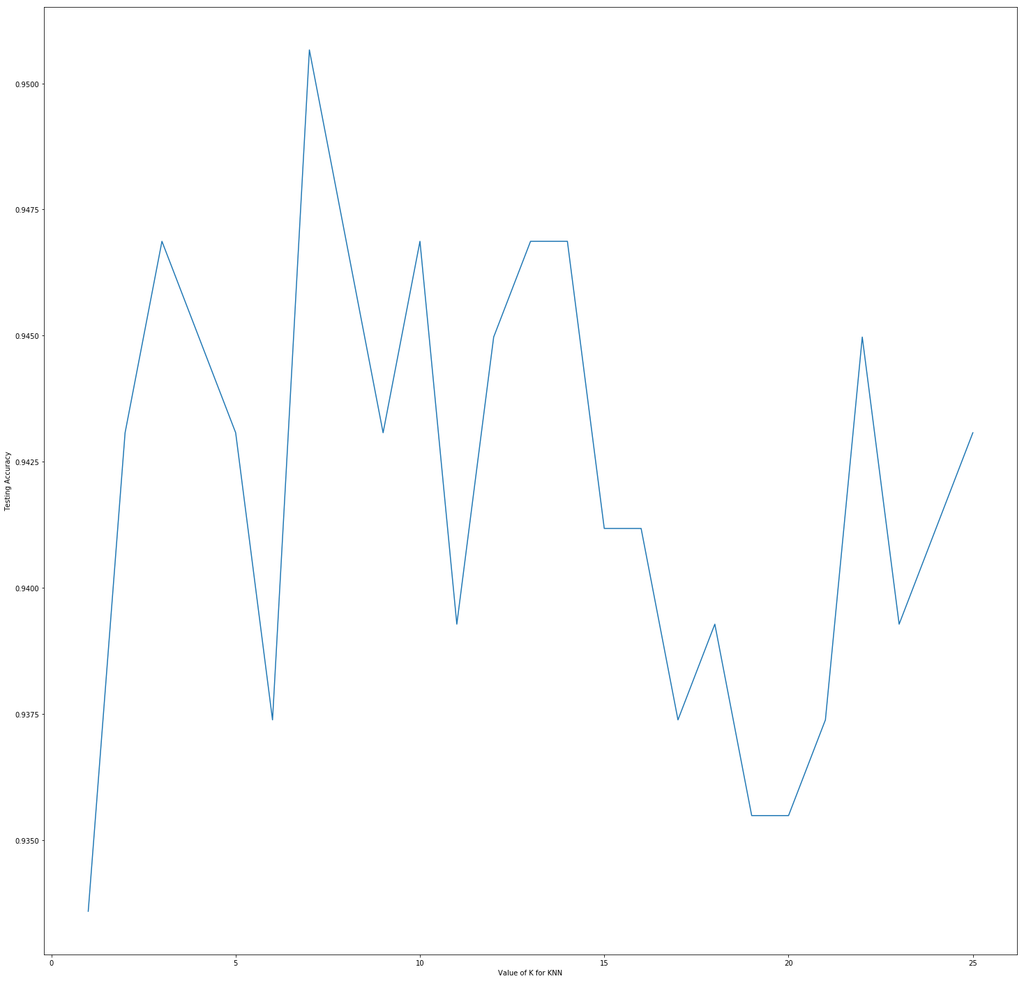

```python
# plot the relationship between K and testing accuracy
# plt.plot(x_axis, y_axis)
#set the plot size
plt.rcParams['figure.figsize'] = (25, 25)
plt.plot(k_range, scores)
plt.xlabel('Value of K for KNN')
plt.ylabel('Testing Accuracy')
```

### the best value for k is 7, and it has training accuracy of 0.95066413662239091, which is also pretty high

### Conclusion5:

both Logistic regression and K-nearest Neighbors (KNN) Classification Model can predict if the country has relative freedom or not, because both of them have high training accuracy

## 5. Reference

- Economic Freedom Dataset of the World: https://www.kaggle.com/gsutters/economic-freedom
- Scatter Matrix Plot: https://pandas.pydata.org/pandas-docs/stable/visualization.html#scatter-matrix-plot
- Logistic Regression: https://www.ritchieng.com/logistic-regression/
- training accuracy: http://pages.cs.wisc.edu/~dpage/cs760/evaluating.pdf
- Train/Test Split: https://towardsdatascience.com/train-test-split-and-cross-validation-in-python-80b61beca4b6